# Molecular Marker Assisted Plant Breeding

Bulk Segregant Analysis (BSA)

Felipe Ferrão

University of Florida

**Objectives:**

- 60 minutes of hands-on
- Introduction to BSA
- Example using BSA-seq data

**Extra information**

- [HOS 6236 – Website](https://lfelipe-ferrao.github.io/class/mas/)
- About the [author](https://lfelipe-ferrao.github.io/)
- About the [UF/IFAS Plant Breeding](https://programs.ifas.ufl.edu/plant-breeding/)

# Introduction

Bulk Segregant Analysis (BSA) is a rapid and cost-effective genetic mapping approach used to identify genomic regions associated with specific traits. Originally developed for use with molecular markers, BSA has been adapted to high-throughput sequencing (BSA-Seq), enabling genome-wide discovery of trait-linked loci. The method involves selecting individuals from the extreme ends of a segregating population (e.g., top and bottom performers for a given trait), pooling their DNA into two contrasting “bulks,” and sequencing them. By comparing allele frequencies between the bulks, researchers can detect significant differences that point to candidate regions controlling the trait. BSA is particularly useful for traits with **simple genetic architecture** and has been widely applied in crop improvement, including in QTL mapping, marker development, and early-stage breeding programs.

In the example below, we show a simple illustration on the use of BSA-seq and show how the QTL identification can be based on measuring the alelic differences observed across both bulks. In the sequence, we will present more details about the methods.

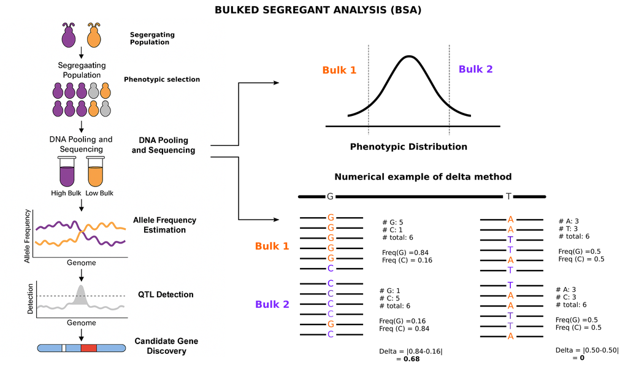

Illustration about the use of BSA-seq. As a statistical analysis, we report the use of the delta method, that compare the allele frequency across the bulks

# Methods

## How to design my BSA-seq experiment

In a recent paper, [Wang et al., (2023)](https://www.sciencedirect.com/science/article/pii/S2211124723010501?via%3Dihub) presented multiple aspects related to modern analyses to BSA analyses. The authors summarized in a single figure, key aspects related to BSA implementation:

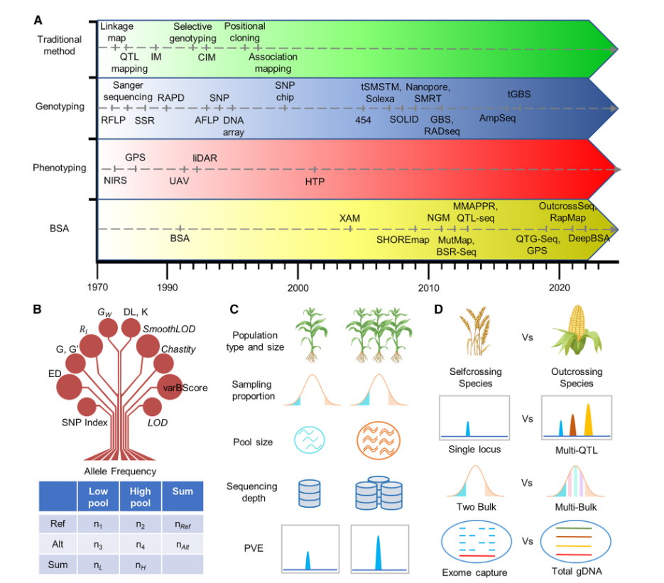

The figure can be divided in four main panels:

1. Timeline comparing different methods and technologies
2. Statistical methods used
3. Factors influencing BSA.
4. Different flavors and options for BSA analyses

Based on the review, there are some important trends when designing a BSA-seq experiments:

- For a given population size, the power of QTL detection increases with sampling fraction, reaching its peak when 20%–25% of the population is sampled.
- Sequencing coverage is also an important factor that determines mapping resolution. Simulations have revealed that higher sequencing coverage decreases the mapping interval for the candidate gene. On average, studies have reported coverage ranging from 30-100x for higher resolution.
- QTL effects and heritability have influence.
- Trade off: population size vs. sequencing depth. Authors suggested that a relatively low sequencing coverage should be used for a large pool size.

**Successful examples of BSA in crops**

- [Takagi et al., (2015)](https://www.nature.com/articles/nbt.3188). MutMap accelerates breeding of a salt-tolerant rice cultivar. Nature Biotechnology.
- In rice, a salt-tolerant mutant, hst1 (hitomebore salt tolerant 1), was identified from 6,000 ethyl methanesulfonate mutant lines of ‘‘Hitomebore,’’ a local elite cultivar in Japan

## Delta SNP index

Many BSA methods are available for both quantitative and qualitative loci. Before showing the use of the delta method, the implementation of BSA-seq experiment involves five main steps:

1. Creating a segregating population (F₂, RILs, etc.)
2. Selecting individuals from the extreme ends of a phenotypic distribution.
3. Pooling DNA from these individuals into two bulks (e.g., high vs. low trait).
4. Sequencing the bulks.
5. Comparing **allele frequencies** at each SNP to find regions with significant differences.

Among the different methods, the **delta SNP index** relies on computing the proportion of reads supporting the **alternate allele** at a given SNP locus, and therefore, it provides an easy quantification of different allele frequencies across the different bulks.

$$\text{SNP index} = \frac{\text{# reads with alternate
allele}}{\text{total reads at that SNP}}$$

$$\Delta = |\text{SNP index}_{\text{High Bulk}} - \text{SNP
index}_{\text{Low Bulk}}|$$

- A **large ΔSNP** indicates the SNP is likely associated with the trait (possible QTL).
- A **small ΔSNP** suggests no association.

To test whether the allele frequency difference is statistically significant, we use **Fisher’s Exact Test** (especially appropriate for low read depths). TO this end, we will use a 2×2 contingency table and test the null hypothesis of **no association** between allele frequency and bulk type. Let’s consider two SNPs: one is a QTL (SNP1), the other is neutral (SNP2). Sequencing depth is 10 reads per bulk per SNP.

| SNP | Bulk | Ref Reads | Alt Reads | Total Reads |
| --- | --- | --- | --- | --- |
| SNP1 (QTL) | High | 2 | 8 | 10 |
| SNP1 | Low | 8 | 2 | 10 |
| SNP2 (No QTL) | High | 5 | 5 | 10 |
| SNP2 | Low | 5 | 5 | 10 |

**SNP1**:

- High Bulk:  
  SNP index = 8 / (2 + 8) = **0.80**
- Low Bulk:  
  SNP index = 2 / (8 + 2) = **0.20**

**ΔSNP (SNP1)**:
$$\Delta = |0.80 - 0.20| = \textbf{0.60}$$

**SNP2**:

- High Bulk: SNP index = 5 / 10 = **0.50**
- Low Bulk: SNP index = 5 / 10 = **0.50**

**ΔSNP (SNP2)**:
$$\Delta = |0.50 - 0.50| = \textbf{0.00}$$

**R code for the statistical test:**

```r
fisher.test(matrix(c(2, 8, 8, 2), nrow = 2))$p.value
```

```
## [1] 0.02301414
```

# Hands-on

Several BSA-Seq analysis methods have been reported in the literature. In this study, we employ the `QTLseqr package`, which offers a robust framework for identifying trait-associated loci. Detailed methods and tutorials are available through the [package documentation](https://github.com/bmansfeld/QTLseqr/tree/master).

- [Mansfeld and Grumet, (2018)](https://acsess.onlinelibrary.wiley.com/doi/10.3835/plantgenome2018.01.0006). QTLseqr: An R Package for Bulk Segregant Analysis with Next-Generation Sequencing. The Plant Genome.

## The rice example

- [Yang et al., 2013](https://journals.plos.org/plosone/article?id=10.1371/journal.pone.0068433) Mapping of Quantitative Trait Loci Underlying Cold Tolerance in Rice Seedlings via High-Throughput Sequencing of Pooled Extremes. Yang Z, Huang D, Tang W, Zheng Y, Liang K, et al. (2013) PLOS ONE 8(7): e68433.
- Mapping of quantitative trait loci (QTLs) controlling cold tolerance is important for rice breeding
- F3 population (10,800 individuals)
- Bulks:
  - Bulk 1: 430 extremely sensitive (ES) individuals
  - Bulk 2: 385 extremely tolerant (ET) individuals
- Marker number: 456,777 SNPs

### Download the data

Files could be in different format. The most common are VCF files.

**R codes**

```r
# DOWNLOAD THE DATA SET #

library("QTLseqr")
setwd("/home/felipe/Dropbox (UFL)/classes/Molecular_Breeding/class4_BSA")

# Define some parameters
HighBulk <- "SRR834931"
LowBulk <- "SRR834927"
Chroms <- paste0(rep("Chr", 12), 1:12)
rawData <- "./Yang_et_al_2013.table"

# Importing from a GATK
tmp = read.table(rawData,header = T)
head(tmp)
```

```
##   CHROM   POS REF ALT SRR834927.AD SRR834927.DP SRR834927.GQ SRR834927.PL
## 1  Chr1 31071   A   G        34,36           70           99    897,0,855
## 2  Chr1 31478   C   T        34,52           86           99   1363,0,844
## 3  Chr1 33667   A   G        20,48           68           99   1331,0,438
## 4  Chr1 34057   C   T        38,40           78           99   1059,0,996
## 5  Chr1 35239   A   C        25,36           61           99    987,0,630
## 6  Chr1 38389   T   C        36,42           78           99   1066,0,906
##   SRR834931.AD SRR834931.DP SRR834931.GQ SRR834931.PL
## 1        26,22           48           99    522,0,698
## 2        40,34           74           99   848,0,1099
## 3        24,29           53           99    765,0,599
## 4        29,26           55           99    673,0,772
## 5        40,60          100           99  1632,0,1015
## 6        42,40           82           99   984,0,1105
```

```r
# Importing using native functions from the package a GATK
df <-importFromGATK(file = rawData,
                    highBulk = HighBulk,
                    lowBulk = LowBulk,
                    chromList = Chroms)

head(df)
```

```
##   CHROM   POS REF ALT AD_REF.LOW AD_ALT.LOW DP.LOW GQ.LOW     PL.LOW
## 1  Chr1 31071   A   G         34         36     70     99  897,0,855
## 2  Chr1 31478   C   T         34         52     86     99 1363,0,844
## 3  Chr1 33667   A   G         20         48     68     99 1331,0,438
## 4  Chr1 34057   C   T         38         40     78     99 1059,0,996
## 5  Chr1 35239   A   C         25         36     61     99  987,0,630
## 6  Chr1 38389   T   C         36         42     78     99 1066,0,906
##   SNPindex.LOW AD_REF.HIGH AD_ALT.HIGH DP.HIGH GQ.HIGH     PL.HIGH
## 1    0.5142857          26          22      48      99   522,0,698
## 2    0.6046512          40          34      74      99  848,0,1099
## 3    0.7058824          24          29      53      99   765,0,599
## 4    0.5128205          29          26      55      99   673,0,772
## 5    0.5901639          40          60     100      99 1632,0,1015
## 6    0.5384615          42          40      82      99  984,0,1105
##   SNPindex.HIGH   REF_FRQ     deltaSNP
## 1     0.4583333 0.5084746 -0.055952381
## 2     0.4594595 0.4625000 -0.145191703
## 3     0.5471698 0.3636364 -0.158712542
## 4     0.4727273 0.5037594 -0.040093240
## 5     0.6000000 0.4037267  0.009836066
## 6     0.4878049 0.4875000 -0.050656660
```

**SNP Information**

- `CHROM` - The chromosome this SNP is in
- `POS` - The position on the chromosome in nt
- `REF` - The reference allele at that position
- `ALT` - The alternate allele

**Sequencing information**

- `DP.HIGH` - The read depth at that position in the high bulk
- `AD_REF.HIGH` - The allele depth of the reference allele in the high bulk
- `AD_ALT.HIGH` - The alternate allele depth in the the high bulk
- `GQ.HIGH` - The genotype quality score, (how confident we are in the genotyping)

**Some statistics**

- `SNPindex.HIGH` - The calculated SNP-index for the high bulk
- `deltaSNP` - differences in the allele frequency

### SNP filtering

Filtering is mainly based on read depth for each SNP, such that we can try to eliminate SNPs with low confidence, due to low coverage, and SNPs that may be in repetitive regions and thus have inflated read depth.

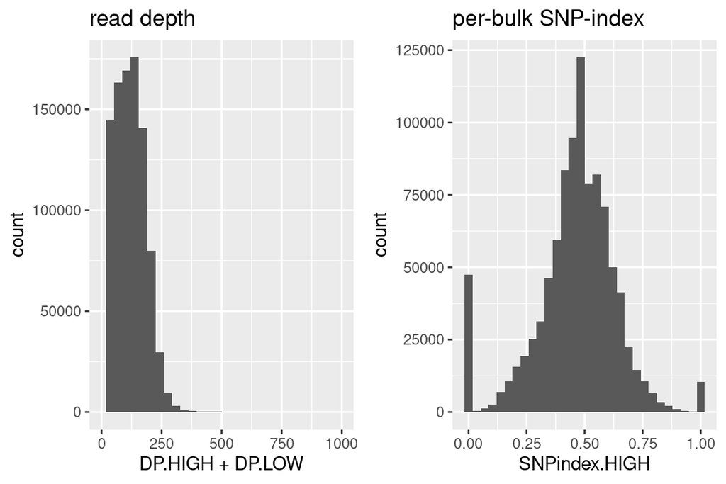

```r
library(ggplot2)
library(gridExtra)

# SNP quality
p1 = ggplot(data = df) +
  geom_histogram(aes(x = DP.HIGH + DP.LOW)) +
  xlim(0,1000) +
  ggtitle("read depth")

p2 = ggplot(data = df) +
  geom_histogram(aes(x = SNPindex.HIGH))+
  ggtitle("per-bulk SNP-index")

grid.arrange(p1,p2,ncol=2)
```

**Important**

- We expect to find two small peaks on each end. This represents SNPs qith different allele frequencies and therefore candidate to be QTL.
- Most of the SNPs should be approximately normally distributed.

```r
# Filtering
df_filt <-
  filterSNPs(
  SNPset = df,
  refAlleleFreq = 0.20,
  minTotalDepth = 100,
  maxTotalDepth = 400,
  depthDifference = 100,
  minSampleDepth = 40,
  minGQ = 99,
  verbose = TRUE
)
```

### QTLseq analysis

Here we will present the method specified by [Takagi et al. (2013)](https://onlinelibrary.wiley.com/doi/full/10.1111/tpj.12105) and described in the `QTLseqr` package.

The analysis is based on calculating the allele frequency differences, using the delta method explained before. To determine regions of the genome that significantly differ from the expected delta values, we used a bootstrap approach, and the extreme quantiles are used as simulated confidence intervals.

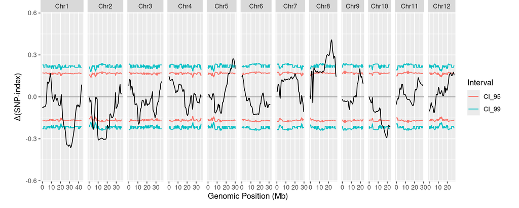

```r
# Coimputing the delta SNP
df_filt2 <- runQTLseqAnalysis(df_filt,
  windowSize = 1e6,
  popStruc = "F2",
  bulkSize = c(385, 430),
  replications = 10000,
  intervals = c(95, 99)
)

# Ploting the results
plotQTLStats(SNPset = df_filt2, var = "deltaSNP", plotIntervals = TRUE)
```

```r
# Extracting the results
results <- getQTLTable(SNPset = df_filt2, method = "QTLseq",interval = 99, export = FALSE)
results
```

```
##    CHROM qtl    start      end   length nSNPs avgSNPs_Mb peakDeltaSNP
## 1   Chr1   1 23933607 35255056 11321449 26284       2322   -0.3630810
## 2   Chr2   2  4194999  4234018    39019     4        103   -0.2190126
## 3   Chr2   3  4237426  5128242   890816  1905       2138   -0.2331216
## 4   Chr2   4  9575918 19955878 10379960 24383       2349   -0.3086188
## 5   Chr2   5 20065798 20108558    42760   116       2713   -0.2144206
## 6   Chr2   6 20758689 21668586   909897  2125       2335   -0.2221694
## 7   Chr5   7 26243037 29805302  3562265  5213       1463    0.2725395
## 8   Chr8   8 16034480 27556093 11521613 23750       2061    0.4082140
## 9  Chr10   9 15477889 16246282   768393  2598       3381   -0.2256715
## 10 Chr10  10 16380493 21022914  4642421 13823       2978   -0.2922702
##    posPeakDeltaSNP avgDeltaSNP
## 1         31110319  -0.3113104
## 2          4234018  -0.2181726
## 3          4510008  -0.2307701
## 4         10121163  -0.3004296
## 5         20065798  -0.2130335
## 6         21668586  -0.2185635
## 7         27618538   0.2636768
## 8         23525616   0.3125763
## 9         16246282  -0.2168116
## 10        19575461  -0.2646124
```

## BSA-seq desing

[Huag et al., (2021)](https://pmc.ncbi.nlm.nih.gov/articles/PMC8727994/) investigated via simulation key aspects related to Optimization of BSA-seq experiment for QTL mapping design.The authors stressed that experimental design for BSA-seq, in general, involves three key aspects or decisions from breeders:

- Population type
- Population size
- Pool proportion (the ratio of pool size to population size)

```r
library("shiny")
runGitHub("BSA-seqDesignTool","huanglikun","main")
```

Below, an example from the app:

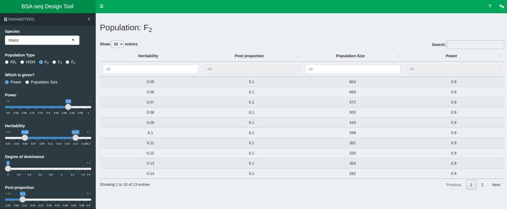

Example about statistical power for BSA-seq analyses reported for Maize, using different genetic architecture

# References

- [Huang et al., 2021](https://academic.oup.com/g3journal/article/12/1/jkab370/6428533). Optimization of BSA-seq experiment for QTL mapping. G3 journal
- [Mansfeld and Grumet, (2018)](https://acsess.onlinelibrary.wiley.com/doi/10.3835/plantgenome2018.01.0006). QTLseqr: An R Package for Bulk Segregant Analysis with Next-Generation Sequencing. The Plant Genome.
- [Yang et al., 2013](https://journals.plos.org/plosone/article?id=10.1371/journal.pone.0068433) Mapping of Quantitative Trait Loci Underlying Cold Tolerance in Rice Seedlings via High-Throughput Sequencing of Pooled Extremes. Yang Z, Huang D, Tang W, Zheng Y, Liang K, et al. (2013) PLOS ONE 8(7): e68433.
- [Wang et al., 2023](https://www.sciencedirect.com/science/article/pii/S2211124723010501?via%3Dihub) Next-generation bulked segregant analysis for Breeding 4.0. Cell Reports